# Avoid the R-oot of All Evil

1/31/2018

## A Little Scenario

- Your script takes 30 minutes to run
- You can only go get coffee so many times in a day
- You remember "someone told me for loops are slow"
- You take a half a day to get rid of them all
- Now your script takes 29 minutes and 55 seconds to run
- You fling your coffee at the wall of your office

## A Similar Scenario

- Your bike feels sluggish on your way to work
- You remember "someone told me carbon components make your bike lighter"
- You buy expensive carbon components
- Your bike still feels slow
- Your brake pads have been rubbing on your wheels

## Wisdom from Donald

Donald Knuth, creator of TeX and general computer science titan, once gave some sound advice:

> "The real problem is that programmers have spent far too much time worrying about efficiency in the wrong places and at the wrong times; **premature optimisation is the root of all evil** (or at least most of it) in programming."

## Ground We'll Cover Today

- So many topics to cover, so I'll go for breadth, not depth (this isn't an `apply` tutorial)
- I'll try to arm you with tools to optimize strategically
- I'll also hit some low-hanging fruit that apply across contexts
- Remember, R is really broad and flexible, so it's my way or one of a hundred highways
- Also there are lots of puns

## Getting the Lay of the Land

- First thing we want to do is figure out our optimization targets
- R has a built-in feature, `Rprof()`
- However, `Rprof()` is evil
- Not really, it's just hard to use

## A Savior!

Meet your new best friend, `profvis()`

```r
first_profile <- profvis({
times <- 4e5
cols <- 150
data <- as.data.frame(x = matrix(rnorm(times * cols, mean = 5), ncol = cols))
data <- cbind(id = paste0("g", seq_len(times)), data)
data1 <- data
means <- apply(data1[, names(data1) != "id"], 2, mean)
for (i in seq_along(means)) {
  data1[, names(data1) != "id"][, i] <- data1[, names(data1) != "id"][, i] - means[i]
}
}, height = "400px")
```

## `profvis()` results

[interactive chart not shown]

## RStudio Built-In

- In RStudio, you can use a built-in feature
- Select some lines of code, then go up to the Profile drop-down menu up top (between Debug and Tools)
- Use "Profile Selected Lines"

## Finer-Scale Timing

- `microbenchmark` is a nice way to check speeds of several similar functions
- It will run many times, since results are stochastic

```r
microbenchmark(
import("AllYearsTeamRatings.csv"),
read_csv("AllYearsTeamRatings.csv"),
read.csv("AllYearsTeamRatings.csv"))
```

```
## Unit: milliseconds
##                                 expr       min        lq      mean
##    import("AllYearsTeamRatings.csv")  2.115346  2.348839  2.991169
##  read_csv("AllYearsTeamRatings.csv")  7.914995  9.217177 11.523115
##  read.csv("AllYearsTeamRatings.csv") 10.750798 11.794113 13.568846
##     median        uq       max neval
##   2.687507  3.606603  5.914044   100
##  10.750853 12.639970 31.562940   100
##  13.258859 14.758336 24.995492   100
```

## PassI/Onate About Speed

- As our previous results show, import speeds can vary a lot
- Input/Output (I/O) can be a bottleneck sometimes
- `rio` package is smart, picks fastest function based on file type
- `import()` and `export()` automatically detect file extension
- Consider using a different file extension for data you'll be using within a computing environment

## CSV vs. feather

```r
data <- data.frame(rnorm(100000))
microbenchmark(write_csv(data, "test_file.csv"),
               write_feather(data, "test_file.feather"))
```

```
## Unit: microseconds
##                                      expr       min        lq      mean
##          write_csv(data, "test_file.csv") 26244.817 29110.962 32999.258
##  write_feather(data, "test_file.feather")   705.415   848.259  1127.477
##    median        uq       max neval
##  32101.99 36287.183 49062.102   100
##   1057.76  1192.169  5231.326   100
```

## CSV vs. feather

```r
microbenchmark(read_csv("test_file.csv"),
               read_feather("test_file.feather"))
```

```
## Unit: microseconds
##                               expr       min         lq      mean
##          read_csv("test_file.csv") 29771.354 31911.8180 34072.400
##  read_feather("test_file.feather")   715.554   897.0005  1035.304
##     median        uq      max neval
##  33249.103 35532.128 45619.61   100
##    993.952  1080.688  3220.23   100
```

## How to Make Your Code Fast

[figure not shown]

## Poor, Misunderstood `for` Loops

- Often the first thing to get picked on
- They aren't always as bad as people say
- They're often poorly used, but *it's not their fault!*

## What Actually Makes a Loop Slow?

- Here's a stupid example:

```r
microbenchmark({
  A <- 0
  for (i in 1:10000){
    10
    A = A + 1
  }
},
{
  A <- 0
  for (i in 1:10000){
    ((((((10))))))
    A = A + 1
  }
})
```

## What Actually Makes a Loop Slow?

```
## Unit: milliseconds
##                                                                                    expr
##              {     A <- 0     for (i in 1:10000) {         10         A = A + 1     } }
##  {     A <- 0     for (i in 1:10000) {         ((((((10))))))         A = A + 1     } }
##       min       lq     mean   median       uq       max neval
##  2.140892 2.189684 2.419263 2.259309 2.373148  9.503435   100
##  4.604204 4.731414 5.807086 4.955224 5.729023 13.066852   100
```

- Remember, in R, **everything** is a function call (or an object)
- `2 + 3` is actually `+(2,3)`, the function `+` with arguments `2` and `3`
- `(` itself is a function, so using a bunch of them results in lots of function calls and lookups
- Lots of calls in a loop = way more calls in total

## What Actually Makes a Loop Slow?

- `for` loops are slow when written inefficiently
- Memory pre-allocation helps a lot
- Do as much as possible outside the loop (also true for `*apply`)
- Don't avoid loops just to avoid loops

## `*apply` yourself

- Fiery debate over whether `*apply` functions are anything more than "syntactic sugar"
- They **contain loops**, but avoid some overhead and sometimes use faster C code
- Truly vectorized code, like `colMeans()` loops through values in the underlying C/FORTRAN code, which is what makes it so fast

## `*apply` yourself

- Comparing an inefficient, vector-growing `for` loop to `vapply`

```r
loop_square <- function(i){
  results <- NA
  for (i in seq_along(x)) results[i] <- x[i]^2
  return(results)
}
```

```
## Unit: milliseconds
##                                                expr        min         lq
##                                      loop_square(x) 104.668825 110.346275
##  vapply(x, function(z) z^2, FUN.VALUE = numeric(1))   5.032315   5.309289
##        mean     median         uq      max neval
##  180.715547 155.310509 239.097543 387.4288   100
##    7.757777   5.689377   6.223751 115.9620   100
```

## `*apply` yourself

- Comparing a more efficient `for` loop to `vapply`

```r
loop_square <- function(i){
  results <- vector(mode = "double", length = length(x))
  for (i in seq_along(x)) results[i] <- x[i]^2
  return(results)
}
```

```
## Unit: milliseconds
##                                                expr      min       lq
##                                      loop_square(x) 6.901298 7.665233
##  vapply(x, function(z) z^2, FUN.VALUE = numeric(1)) 5.096930 5.665274
##      mean   median       uq      max neval
##  9.317205 8.056315 9.439694 15.40659   100
##  7.163590 5.835056 6.328257 79.98100   100
```

## `*apply` yourself

- Another big benefit is that lots of packages that deal with parallel computing in R include parallelized `apply` functions
- `mclapply()` from `parallel` package is an example of this
- Always remember, `apply` will never beat real vectorized base functions, like `^`

```
## Unit: microseconds
##                                                expr     min       lq
##                                                 x^2   1.389   1.6910
##  vapply(x, function(z) z^2, FUN.VALUE = numeric(1)) 498.146 561.7895
##                                      loop_square(x) 667.767 754.6405
##        mean   median       uq      max neval
##     2.23033   1.8540   2.2585   10.886   100
##   624.46142 590.4550 679.6740 1671.517   100
##  1100.04179 884.1715 976.2215 7590.399   100
```

## Cache Me If You Can

- `memoise` package can cache answers to a function
- If you call the function with the same inputs, it'll remember the old answer

```r
fib <- function(n) {
  if (n < 2) {
    return(n)
  } else {
    return(fib(n-1) + fib(n-2))
  }
}
```

## Cache Me If You Can

```r
system.time(x <- fib(25))
```

```
##    user  system elapsed
##   0.194   0.001   0.195
```

```r
system.time(z <- fib(30))
```

```
##    user  system elapsed
##   2.197   0.014   2.218
```

## Cache Me If You Can

- Now let's `memoise` the function and look at how speed changes

```r
fib_mem <- memoise(fib)
system.time(a <- fib_mem(30))
```

```
##    user  system elapsed
##   2.162   0.010   2.181
```

```r
system.time(b <- fib_mem(30))
```

```
##    user  system elapsed
##   0.001   0.000   0.001
```

## Cache Me If You Can

- A few potential uses:
- You're running a Shiny app and want to store results in case the user selects the same inputs again
- You're applying a function over a dataset where you expect many similar inputs
- You're working on a script and want to save results of some slow calls (similar to caching chunks in RMarkdown)
- Tradeoff here is speed vs. memory

## Cache Me If You Can

- Very dangerous if you're doing some sort of randomization

```r
rnorm_plus1 <- function(x) {
  rnorm(x)+1
}
x <- rnorm_plus1(10)
y <- rnorm_plus1(10)
all.equal(x,y)
```

```
## [1] "Mean relative difference: 0.7456167"
```

```r
rp1_mem <- memoise(rnorm_plus1)
x <- rp1_mem(10)
y <- rp1_mem(10)
all.equal(x,y)
```

```
## [1] TRUE
```

## Take a Big Ole Byte (Compiler)

- R is interpreted, not compiled when it's run
- Just-In-Time compiler compiles your code into bytecode, "just in time" to be run
- If you're running R 3.3 or earlier, JIT compiler is not turned on by default
- In R 3.4, JIT is turned on by default
- value passed to `enableJIT()` changes how many types of functions get compiled (3 is the most)

## Take a Big Ole Byte (Compiler)

- Here we're comparing `enableJIT(3)` to `enableJIT(0)`
- The (boring) function that we create will get used 100 times

```
## Unit: milliseconds
##                                                                                                          expr
##  {     enableJIT(3)     f <- function(n, x) for (i in 1:n) x = (1 + x)^(-1)     for (i in 1:100) f(1000, 1) }
##  {     enableJIT(0)     f <- function(n, x) for (i in 1:n) x = (1 + x)^(-1)     for (i in 1:100) f(1000, 1) }
##       min       lq     mean   median       uq      max neval
##  13.61056 14.50980 18.11377 15.68746 18.84249 40.13041    50
##  43.61722 54.71553 57.86644 56.85857 61.14517 73.63988    50
```

## Take a Big Ole Byte (Compiler)

- Same comparison, but the function we create is only getting used once

```
## Unit: microseconds
##                                                                                         expr
##  {     enableJIT(3)     f <- function(n, x) for (i in 1:n) x = (1 + x)^(-1)     f(1000, 1) }
##  {     enableJIT(0)     f <- function(n, x) for (i in 1:n) x = (1 + x)^(-1)     f(1000, 1) }
##       min       lq     mean    median       uq       max neval
##  3081.475 3324.188 4093.859 3544.8845 3940.925 15638.276    50
##   394.830  424.662  550.846  489.8965  595.829  1262.411    50
```

- If a function only gets called once, compiling it can bring overhead costs

## Take a Big Ole Byte (Compiler)

- Be careful though, JIT compiler is turned to 3 by default in R 3.4, and sometimes JIT can be slower
- These are results from an Integral Projection Model script

## Take a Big Ole Byte (Compiler)

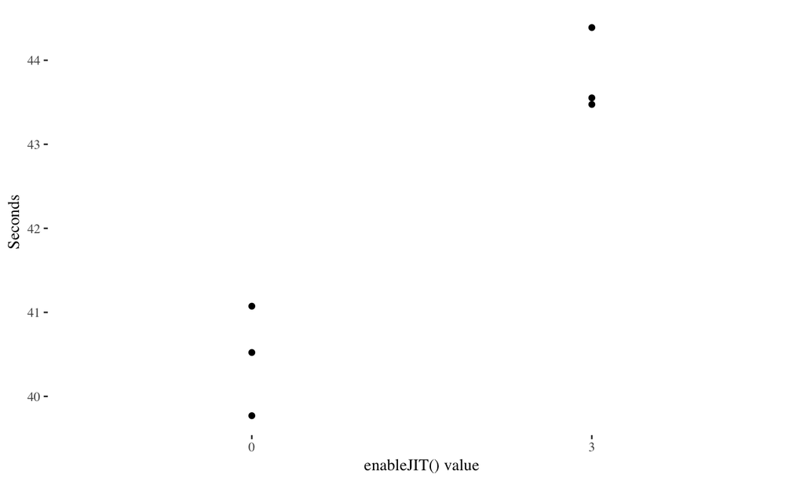

## Take a Big Ole Byte (Compiler)

- You can also compile individual functions with `cmpfun`

```
## [1] 0
```

```r
x <- rnorm(10000)
ls_pre_compile <- cmpfun(loop_square)
```

```
## Unit: milliseconds
##               expr      min       lq    mean   median       uq       max
##     loop_square(x) 6.716031 7.039205 8.92701 7.530853 8.822790 21.367198
##  ls_pre_compile(x) 1.286016 1.319457 1.43942 1.388008 1.493602  2.306523
##  neval
##    100
##    100
```

## Take a Big Ole Byte (Compiler)

- What if we take the compilation time into consideration?

```
## Unit: milliseconds
##                                                         expr      min
##  {     ls_compile <- cmpfun(loop_square)     ls_compile(x) } 4.813064
##                                               loop_square(x) 6.674617
##                                            ls_pre_compile(x) 1.287220
##        lq      mean   median       uq       max neval
##  5.322293  6.056607 5.571190 5.923528 16.305290   100
##  7.151581 10.069041 7.735404 9.040673 37.356751   100
##  1.364575  1.431512 1.403437 1.466179  2.015202   100
```

- It's faster even if you include the compilation step!
- Some functions benefit more from compiling than others
- Individual compilation may not make much of a difference in R 3.4, where `enableJIT(3)` is the default

## It's My Computer's Fault

- Sometimes an excuse, sometimes true
- [Benchmarking scripts](http://r.research.att.com/benchmarks/) to see how fast your computer is
- `benchmarkme` package, `benchmark_std()` function
- Virtual machines through [Google](https://cloud.google.com/compute/) or [Amazon](https://aws.amazon.com/free/)
- Don't sell the [FARM](https://wiki.cse.ucdavis.edu/support/systems/farm)
- Buy more RAM (if you can)

## Put Your Matrices on BLASt

- BLAS = Basic Linear Algebra Subprograms
- CRAN gives a universal, solid one
- Others are optimized for certain computers
- You can figure out what BLAS library you're using with this function:

```r
library(benchmarkme)
get_linear_algebra()
```

- [Here's how to change yours on a Mac](https://gist.github.com/zachmayer/e591cf868b3a381a01d6#file-veclib-sh)

## R-ecipe For Success

- First do the one-time low-hanging fruit (BLAS)
- Profile your code, identify targets AND speed goals
- Decide which targets are worth the work/learning to fix
- Test some alternatives, use benchmarking/profiling
- Keep your old versions for future reference
- For goodness sake, **use base functions**

**Remember- being strategic and disciplined is good, but nobody is perfect, and experimentation/playing around can be an important part of learning**

## Things to Keep in Mind

- How much you'll use your code
- How bad is the learning curve
- How much time you have as a researcher
- R is not a fast language

**If you're crunched for time, learning a new method will take a while, and you'll never use this script again, why optimize it?**

## Credit Where It's Due

I got a lot of the information from these sources, among others:

[Efficient R Programming by Colin Gillespie](https://csgillespie.github.io/efficientR/index.html): This book covers a **HUGE** range of topics and is really well written.

[Noam's D-RUG talk from 2013](https://d-rug.github.io/blog/2013/faster-talk) and [his blog post on vectorization](http://www.noamross.net/blog/2014/4/16/vectorization-in-r--why.html)

[Hadley Wickham's Advanced R](http://adv-r.had.co.nz/): I particularly used the [Performance](http://adv-r.had.co.nz/Performance.html) and [Profiling](http://adv-r.had.co.nz/Profiling.html) chapters

[An Article on For Loops in an R Newsletter From 2008](https://www.r-project.org/doc/Rnews/Rnews_2008-1.pdf)

[Lots](https://stackoverflow.com/questions/28983292/is-the-apply-family-really-not-vectorized) [of](https://stackoverflow.com/questions/2275896/is-rs-apply-family-more-than-syntactic-sugar) [Stack](https://stackoverflow.com/questions/7142767/why-are-loops-slow-in-r) [Overflow](https://stackoverflow.com/questions/5533246/why-is-apply-method-slower-than-a-for-loop-in-r?noredirect=1&lq=1)

[R Inferno by Patrick Burns](https://www.burns-stat.com/pages/Tutor/R_inferno.pdf): If you want to slowly descend into infernal torment of R knowledge, really dig into this book